# Quantitative proteomic analysis

Author

Romanos Siaperas

Published

July 17, 2025

## 1 Introduction

This is the quantitative proteomics analysis. Includes reading the output files of [quantms](https://quantms.org/home) and quantitative analysis with prolfqua. I have already functions doing these tasks gathered in the Rscripts_for_proteomics package.

The MS data are available in PXD065010 PRIDE project.

### 1.1 Experimental setup

For an extended analysis of batches see the corresponding quarto and HTML documents.

Samples were prepared in 2 different batches in the Biotechnology Laboratory from Romanos and Maria (NTUA, Greece) and analyzed in different batches from the VIB Proteomics Core facility with label-free LC-MS/MS (VIB, Belgium). There are 3 different VIB projects but PRC-5442 and PRC-5590 have identical sample preparation (PRC-5590 had just some extra cleaning steps) and MS section and were analyzed in 2021-08 and 2022-01 respectively so will be set in the same MS batch. PRC-6063 was analyzed in 2023-06.

| Sample | Batch | Experiment | VIB project | Filename |
| --- | --- | --- | --- | --- |
| bw_1 | exp2_ms2 | Rom | 6063 | B28553_10ul_IonOpt_PRC6063 |
| bw_2 | exp2_ms2 | Rom | 6063 | B28543_10ul_IonOpt_PRC6063 |
| bw_3 | exp2_ms2 | Rom | 6063 | B28545_10ul_IonOpt_PRC6063 |
| cs_1 | exp1_ms1 | Maria | 5590 | E28115_5ul_PAC_PRC5590 |
| cs_2 | exp1_ms2 | Maria | 6063 | B28547_10ul_IonOpt_PRC6063 |
| cs_3 | exp1_ms2 | Maria | 6063 | B28549_10ul_IonOpt_PRC6063 |
| xyl_1 | exp1_ms1 | Maria | 5442 | E26698_3ul_PAC_PRC5442 |
| xyl_2 | exp1_ms1 | Maria | 5442 | E26704_3ul_PAC_PRC5442 |
| xyl_3 | exp2_ms2 | Rom | 6063 | B28551_10ul_IonOpt_PRC6063 |

### 1.2 The MS data

- The mzTab file sdrf_openms_design_openms.mzTab.gz
- The msstats input file sdrf_openms_design_msstats_in.csv.gz
- The proteome fasta file used for the analysis

The mass spectrometry proteomics data have been deposited to the ProteomeXchange Consortium via the PRIDE (Perez-Riverol et al., 2022) partner repository with the dataset identifier PXD065010 and 10.6019/PXD065010.

**When published will add links to download the files from PRIDE ftp and a script to download all data.**

### 1.3 The analysis

We have **three conditions** with three replicates each. The conditions are:

- secretome after growth with xylose
- secretome after growth with beechwood
- secretome after growth with corn stover

The steps:

- Get some info about proteins and PTMs from mzTab
- Import peptide level intensities in prolfqua
- Normalization at peptide level
- Protein aggregation
- Differential protein abundance testing
- Filter reliably quantified proteins

## 2 Load libraries and data

```r
library(dplyr)
library(tidyr)
library(ggplot2)
library(ggVennDiagram)
library(GGally)

library(limma)
library(prolfqua)
library(DEP)
library(PCAtools)

library(RscriptsForProteomics)

# mzTab
mzt <-"data/MS/sdrf_openms_design_openms.mzTab.gz"
# msstats input
data <- read.csv("data/MS/sdrf_openms_design_msstats_in.csv.gz", header = TRUE, sep = ',')
head(data, 1)
data$Reference <-  paste0(data$Condition, "_r", data$BioReplicate)
head(data, 2)
```

These two functions parse the mzTab and msstats_input to get some stats for each protein like number of PSMs, peptides etc. There are 2 different columns with peptide count:

- opt_global_nr_found_peptides: Number of peptidoforms with PSMs, each different PTM combination is counted
- nr_unmodified_peptides: Number of quantified peptides taken from msstats_input. Each peptide with and without PTMs is counted only once
- peptide_index: The min and max index of the aminoacid sequence with quantified peptides

```r
### Take mzTab info
prot_info <- extract_protein_stats(mzt)
head(prot_info, 2)
```

```
        protein_Id protein_coverage opt_global_nr_found_peptides PSMs
1 AB1N83_000001-R1       0.04166667                            1    1
2 AB1N83_000002-R1       0.62197393                           40  130
```

```r
proteomicslfq_ids_to_keep <- get_proteinIds_from_proteomicslfq(mzt)

### Take peptide info
pep_info <- extract_peptides_per_protein(strip_ptms_from_msstats_in("data/MS/sdrf_openms_design_msstats_in.csv.gz"), "../genome/annotation/proteins.fasta.gz")
head(pep_info, 2)
```

```
        protein_Id nr_theoretical_tryptic_peptides nr_unmodified_peptides
1 AB1N83_005204-R1                             185                     59
2 AB1N83_008079-R1                              84                     13
  peptide_index
1         2-848
2         2-262
                                                                                                                                                                                                                                                                                                            …
1 AAEFDIEATLAK;AGLDIEMPGPTVMR;AMTSGGGSAQLR;ANPWALMTAYNR;ASWVAEAGK;ASWVAEAGKFDVFVGTSSTDIK;AYDIEIR;EALSFYDDR;EALSFYDDRR;EIGAEVTYHIGTPSHNTLPLLDGSIR;EIYLKPFQIAIK;ESFIWK;EVAQVYIADPQSSLPR;EVAQVYIADPQSSLPRPLK;EVAQVYIADPQSSLPRPLKELK;EVIDLEAGK;EVIDLEAGKAYDIEIR;FDVFVGTSSTDIK;FSISSEVSER;FTVTLSIK;GCHVLLAPTVNTQR…
2                                                                                                                                                                                                                                                                                                           …
```

```r
merged_info <- merge(prot_info, pep_info, by = "protein_Id", all = TRUE)

save_gzipped_csv(data.frame(merged_info), "results/MS/unfiltered_MS_data.csv.gz")
```

## 3 Peptide level analysis

### 3.1 PTMs

Will plot the frequency of each post-translational modification separate and then all possible combinations of them. This info will be taken from the mzTab file.

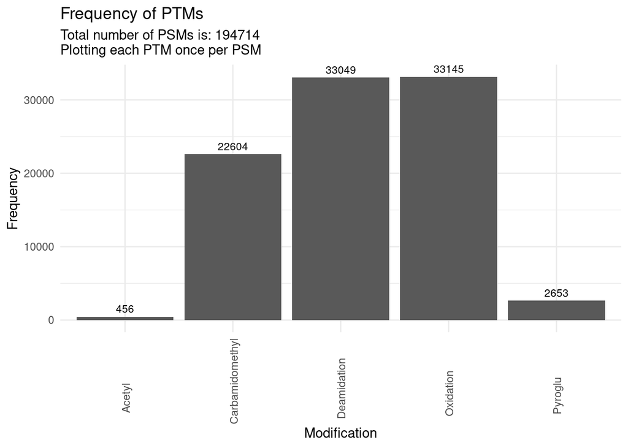

Figure 1: Frequency of each separate PTM

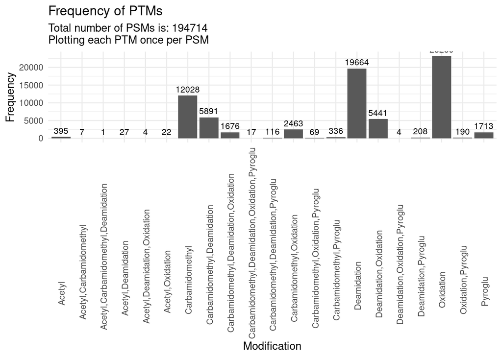

Figure 2: Frequency of each combination of PTMs

```r
count_peptide_modifications(mzt,  plot_type = "separate")
count_peptide_modifications(mzt,  plot_type = "mixed")
```

### 3.2 EDA peptide-level

Import peptide intensities in prolfqua and make some exploratory plots. First will plot cumulative missing values per peptide and the peptide intensities for each biological condition for peptides with 0-2 missing values.

```r
# Import msstats input in prolfqua
lfqdata <- create_lfqdata(data)
# not needed in the output of quantms but anyway
lfqdata$remove_small_intensities()

# raw density plot
density_raw_pep <- lfqdata$get_Plotter()$intensity_distribution_density()

# missing values per group
p1_mv <- lfqdata$get_Summariser()$plot_missingness_per_group()
p2_mv <- lfqdata$get_Plotter()$missigness_histogram()
```

```r
knitr::kable(lfqdata$hierarchy_counts(), caption = "number of proteins and peptides.")
```

number of proteins and peptides.

| isotopeLabel | protein_Id | peptide_Id |
| --- | --- | --- |
| light | 2179 | 21207 |

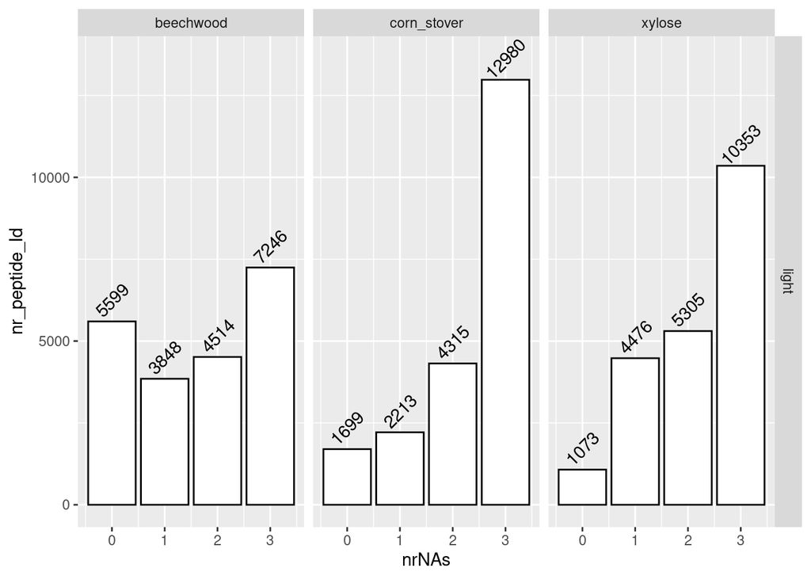

Figure 3: Cumulative peptide MVs per condition

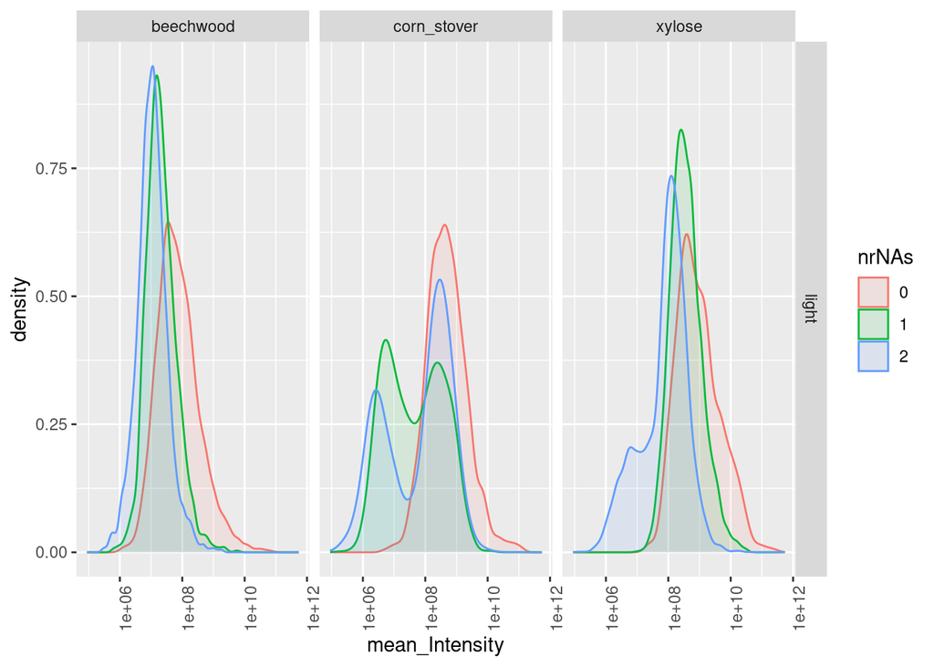

Figure 4: Density of peptides with 0, 1 or 2 MVs per condition.

```r
p1_mv
p2_mv
```

Beechwood is the only condition where all 3 replicates were analyzed in the same batch and has normal distributions. Corn stover in the contrary has two tail distributions for the populations with missing values. This is because the PRC-6063 samples are left-shifted compared to the others (see peptidy densities before normalization as well).

```r
stats <- lfqdata$get_Stats()
prolfqua::table_facade( stats$stats_quantiles()$wide, paste0("quantile of ",stats$stat ))
p1 <- stats$density_median()
p2 <-  stats$violin()
```

Same picture here with the coefficient of variation with corn_stover being the most diverse condition and beechwood the most stable.

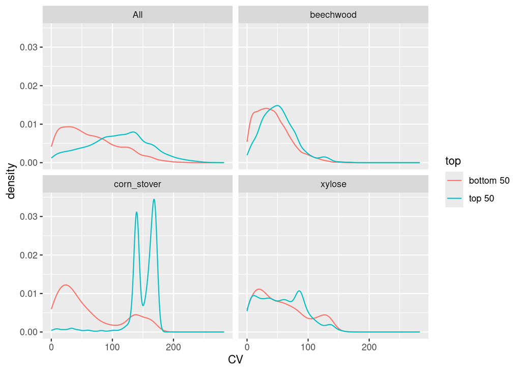

Figure 5: Density of most/least variable peptides

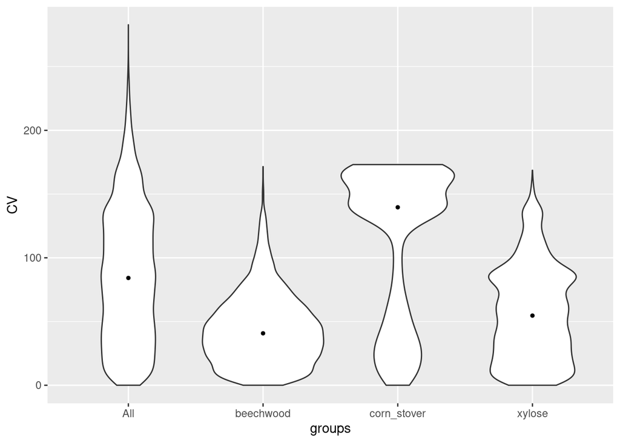

Figure 6: Violit plot of peptide coefficient of variation

```r
p1
p2
```

Next, peptide abundances are log2 transformed and robust z-score scaled using the method robscale.

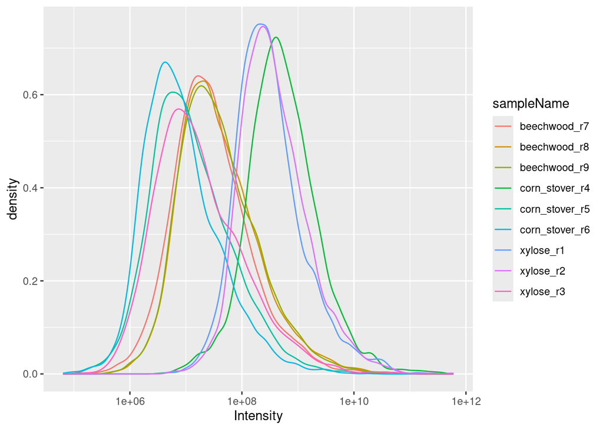

Figure 7: Density of raw peptide intensities

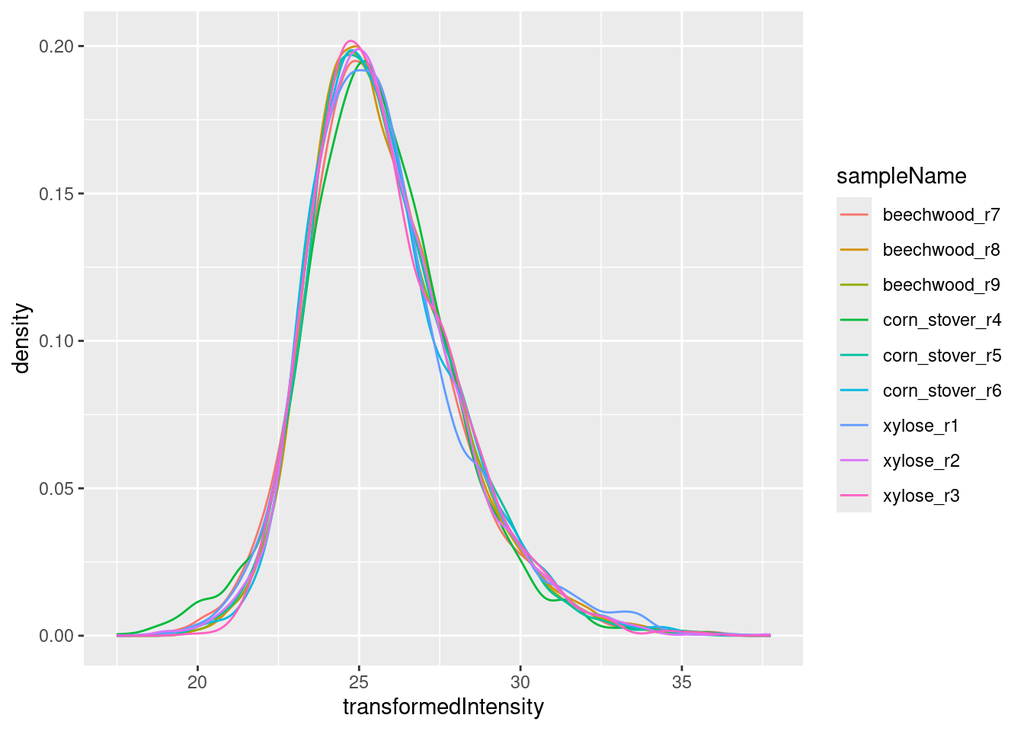

Figure 8: Density of log2 robscaled peptide intensities

```r
lt <- lfqdata$get_Transformer()
lfqdataPeptideNorm <- lt$log2()$robscale()$lfq

density_raw_pep
pl <-  lfqdataPeptideNorm$get_Plotter()
pl$intensity_distribution_density()
```

```
[1] "346 peptides are quantified in all 9 samples and used for PCA (1.6%)"
```

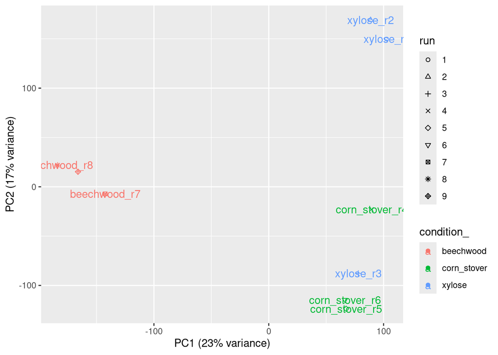

```r
pl$pca()
pep_data <- data.frame(lfqdataPeptideNorm$to_wide()$data)
save_gzipped_csv(data.frame(pep_data), "results/MS/robscaled_peptide_intensities.csv.gz")

pep_df <- data.frame(lfqdataPeptideNorm$to_wide()$data)[,c(4:12)]
rownames(pep_df) <- data.frame(lfqdataPeptideNorm$to_wide()$data)$peptide_Id
paste0(na.omit(pep_df) %>% nrow()," peptides are quantified in all 9 samples and used for PCA (", round(na.omit(pep_df) %>% nrow() / pep_df %>% nrow() * 100, 1), "%)" )
```

## 4 Protein-level analysis

### 4.1 Protein aggregation

Protein intensities were estimated from peptide intensities using Tukey’s median polish (TMP). However, TMP summarization creates artifacts in cases where all peptides of a protein are detected uniquely in single samples, yielding misleading uniform protein intensities across all samples. This phenomenon is previously reported in microarray data summarization (Giorgi et al., 2010). For proteins affected by this artifact, median summarization of the top three peptides was employed instead.

Filtered for reliably quantified proteins -> proteins present in at least 2 replicates of at least one condition.

```r
# protein aggregation
mp_df <- protein_aggregation(lfqdataPeptideNorm)
# keep one protein per protein group
mp_df <- filter_for_leading_protein(mp_df, proteomicslfq_ids_to_keep)
save_gzipped_csv(data.frame(mp_df), "results/MS/protein_intensities.csv.gz")
# save the reliably quantified proteins in a vector for later
mp_df_quant <- filter_proteins_by_replicates(mp_df, c("beechwood", "corn_stover", "xylose"), 2)
```

### 4.2 EDA plots

#### 4.2.1 Protein level

However:

- only 182 proteins without missing values are used in PCA analysis
- The first two PCs do not capture enough variability

Still we will confirm that substrate is the driving force of variation in the DE analysis step as well.

```r
quantified_proteins <- mp_df_quant$protein_Id
rownames(mp_df_quant) <- mp_df_quant$protein_Id
mp_df_quant <- mp_df_quant[,c(2:(length(data$Reference %>% unique()) + 1))]
metadata <- data.frame(row.names = colnames(mp_df_quant))
metadata$Condition <- gsub("^(.*)_r.*$",  "\\1", colnames(mp_df_quant))
p <- PCAtools::pca(na.omit(mp_df_quant), metadata = metadata, removeVar = 0.1)
horn <- parallelPCA(na.omit(mp_df_quant))
elbow <- findElbowPoint(p$variance)
```

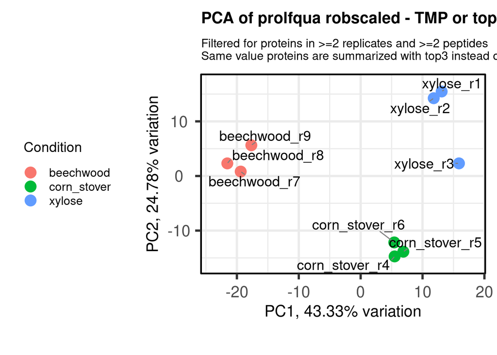

Figure 10: Biplot of the PC1 and PC2 based on 182 proteins without missing values.

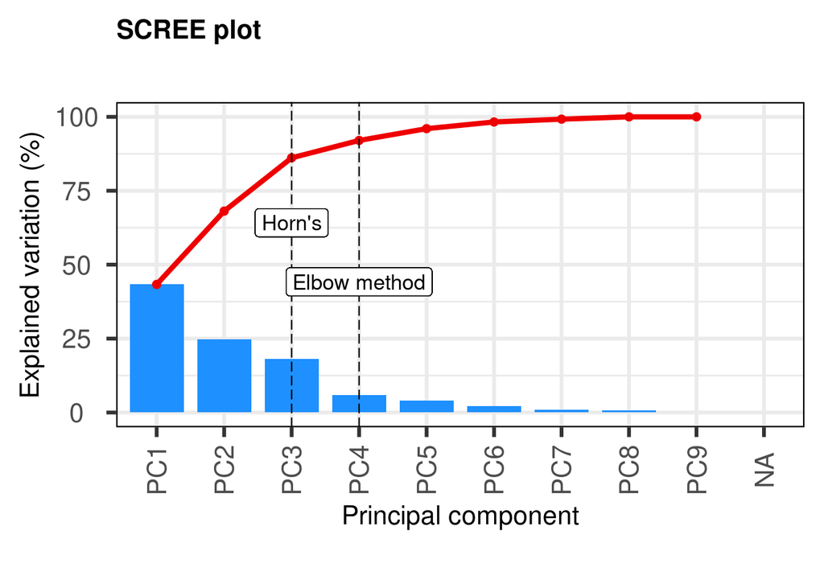

Figure 11: Scree plot of the accumulative proportion of explained variation. Optimum number of PCs to retain based on the Elbow method and Horn’s parallel analysis are highlighted.

```r
PCAtools::biplot(p, colby = "Condition",  title = "PCA of prolfqua robscaled - TMP or top3 summarized protein intensities",
                 subtitle = "Filtered for proteins in >=2 replicates and >=2 peptides\nSame value proteins are summarized with top3 instead of TMP",
                 labSize = 5,legendPosition = "left", pointSize = 5)

PCAtools::screeplot(p,
                    components = getComponents(p, 1:20),
                    vline = c(horn$n, elbow)) +
  geom_label(aes(x = horn$n, y = 50, label = 'Horn\'s', vjust = -1, size = 8)) +
  geom_label(aes(x = elbow, y = 30, label = 'Elbow method', vjust = -1, size = 8))
```

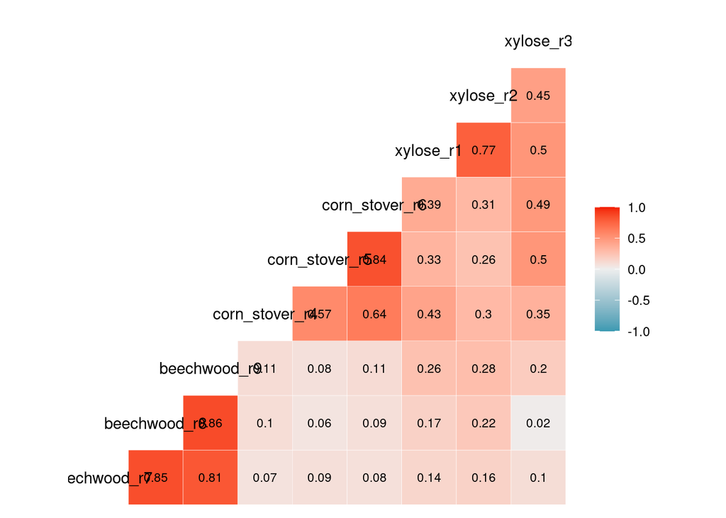

Figure 12: Pearson correlation matrix plot based on protein intensities.

```r
GGally::ggcorr(mp_df_quant, method = c("pairwise", "pearson"), label = TRUE, label_round = 2, label_size = 3)
```

The following plots are based on the [DEP](https://bioconductor.org/packages/release/bioc/html/DEP.html) bioconductor package.

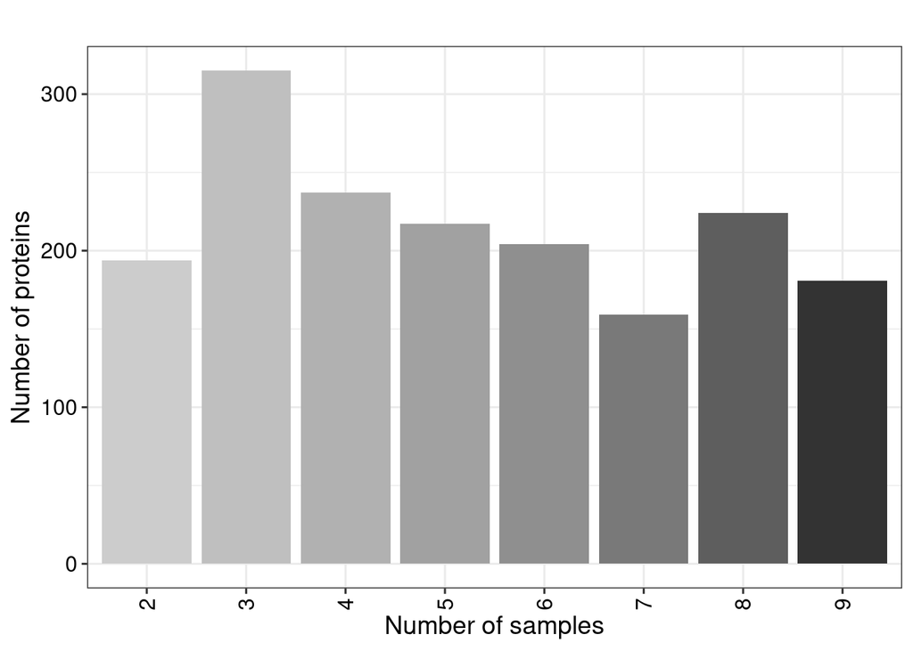

Figure 13: Protein identification overlap.

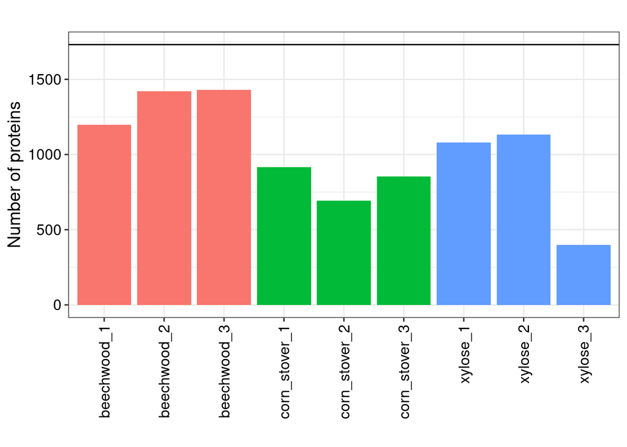

Figure 14: Proteins per sample.

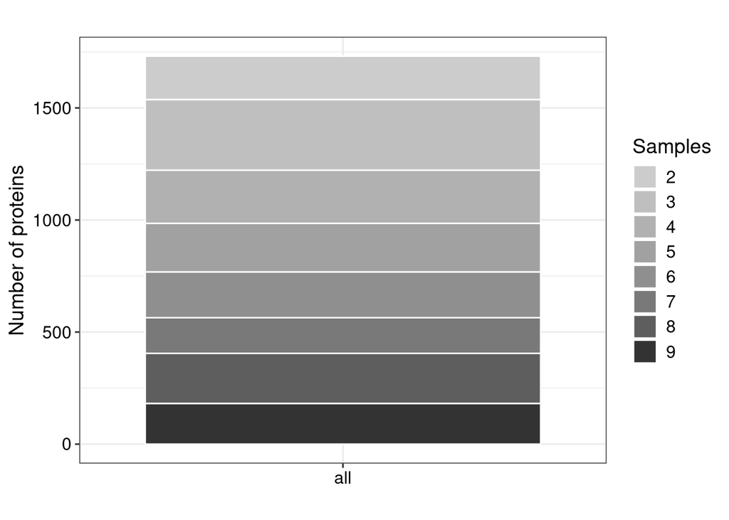

Figure 15: Barplot of the protein identification overlap between samples.

```r
#|#   - "Heatmap of proteins with missing values. Samples and proteins are clustered based on missing values."
#| echo: true

protein_intensities <- tibble::rownames_to_column(mp_df_quant, "proteinId")
condition_cols <- c(2:(length(data$Reference %>% unique()) + 1))
data_se <- DEP:::make_unique(protein_intensities,"proteinId","proteinId",delim=";")
exp_design <- data.frame(
  label =rownames(metadata),
  condition = metadata$Condition,
  replicate = rep(c(1:3),3)
)
data_se<-DEP:::make_se(data_se, condition_cols ,exp_design)

plot_frequency(data_se) + labs(title = "") + xlab("Number of samples")

plot_numbers(data_se) + labs(title = "") + ylab("Number of proteins") +  theme(legend.position = "none")

plot_coverage(data_se) + labs(title = "")

#plot_missval(data_se) + labs(title = "")
```

#### 4.2.2 Susbstrate level

Again we use the reliably quantified proteins here and take the average of the 3 replicates in each sample. One replicate is enough to consider a protein present in this substrate.

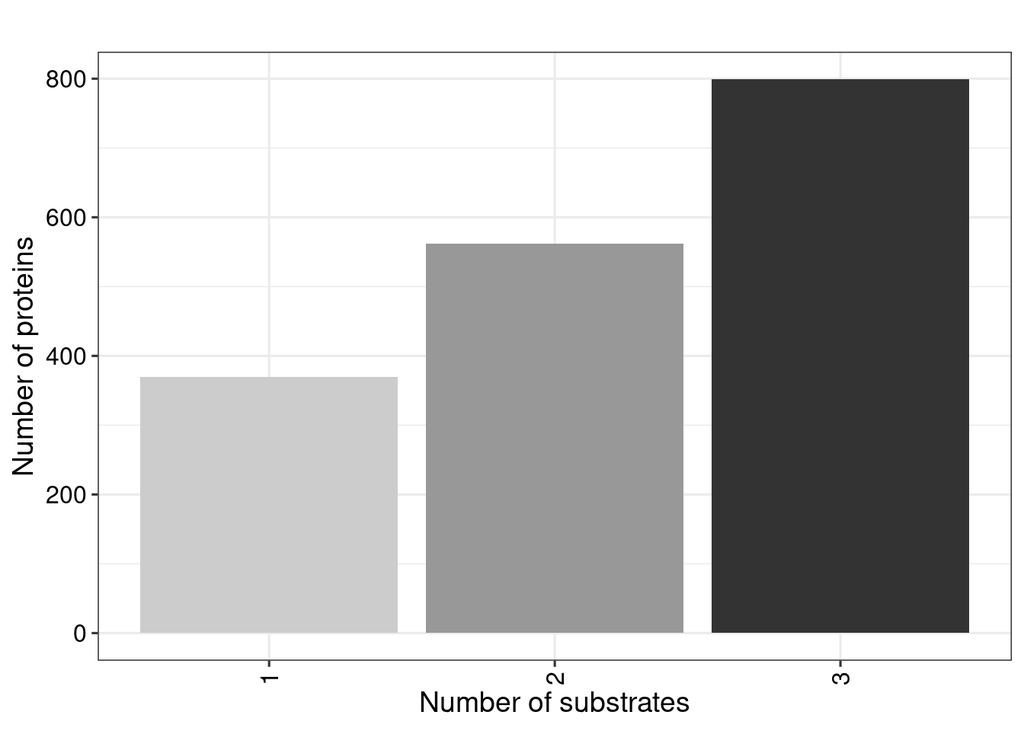

Figure 16: Protein identification overlap.

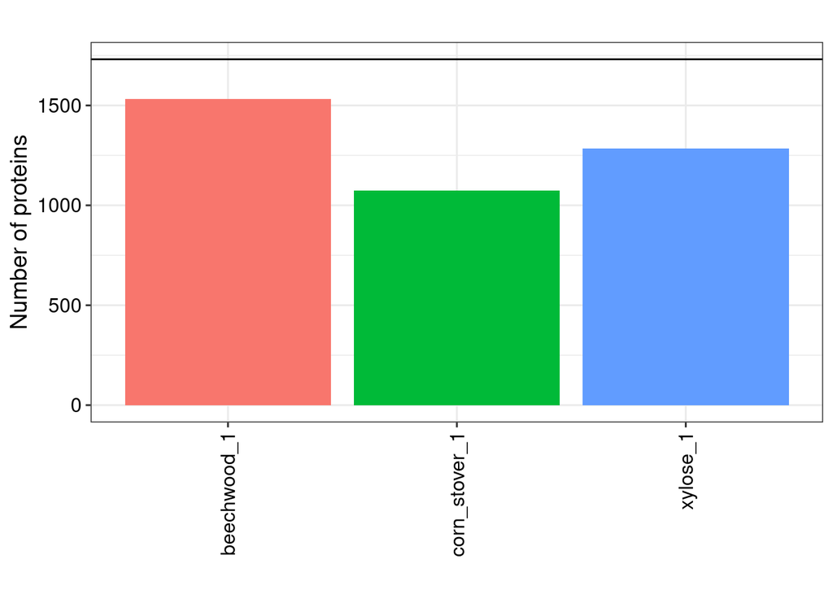

Figure 17: Proteins per substrate.

```r
protein_intensities <- tibble::rownames_to_column(mp_df_quant, "proteinId")
conditions <- unique(data$Condition)

for (condition in conditions) {
  condition_cols <- grep(condition, colnames(protein_intensities), value = TRUE)
  protein_intensities[[paste0(condition, "_s1")]] <- rowMeans(protein_intensities[, condition_cols], na.rm = TRUE)}

condition_cols <- c((length(data$Reference %>% unique()) + 2): (length(data$Reference %>% unique()) + length(conditions) + 1))
data_se <- DEP:::make_unique(protein_intensities,"proteinId","proteinId",delim=";")
exp_design <- data.frame(
  label =paste(conditions, "_s1", sep = ""),
  condition = conditions,
  replicate = rep(c(1),3)
)
data_se<-DEP:::make_se(data_se, condition_cols ,exp_design)

plot_frequency(data_se) + labs(title = "") + xlab("Number of substrates")

plot_numbers(data_se) + labs(title = "") + ylab("Number of proteins") + theme(legend.position = "none")
```

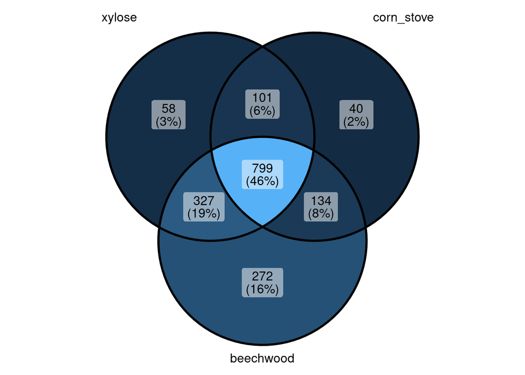

Figure 18: Overlap of quantified proteins in the different substrates.

```r
venn_data <- list(
  xylose = protein_intensities$proteinId[!is.na(protein_intensities[['xylose_s1']])],
  corn_stover = protein_intensities$proteinId[!is.na(protein_intensities[['corn_stover_s1']])],
  beechwood = protein_intensities$proteinId[!is.na(protein_intensities[['beechwood_s1']])]
)

ggVennDiagram(venn_data) +
  theme(legend.position = 'none',
        legend.text = element_text(size = 24))
```

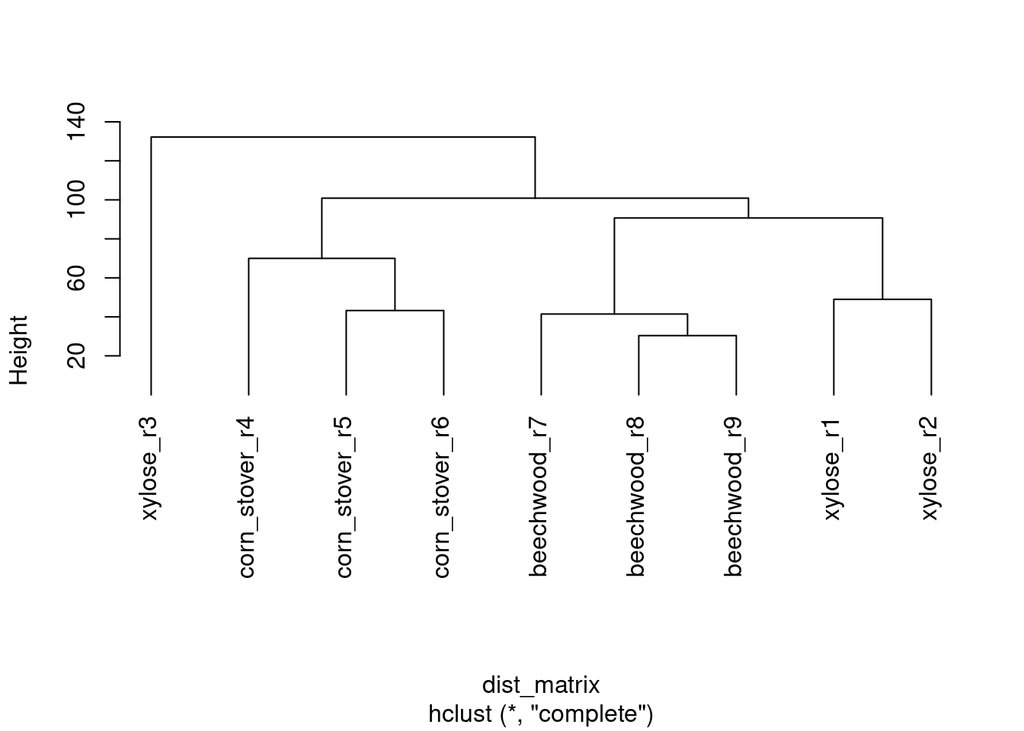

Figure 19: Euclidean clustering dendrogram

```r
transposed_data <- t(mp_df_quant)
dist_matrix <- dist(transposed_data, method = "euclidean")
hclust_result <- hclust(dist_matrix, method = "complete")
plot(hclust_result, hang = -1, main = "")
```

### 4.3 Differential abundance analysis

- We import the protein intensities in prolfqua to perform the differential abundance testing
- We apply the limma moderated t-test for DE analysis. We do an ordinary t-test and then moderate the standard errors accros proteins - we squeeze them towards a common value using a simple Bayesian model.
- We filter for reliably quantified proteins only after running the tests since the unreliable ones contribute to the limit of detection (LOD) estimation (see [prolfqua](https://doi.org/10.1021/acs.jproteome.2c00441) publication’s supplementary file).
- The MS batches are also inserted as covariates in the linear model.

```r
# turn the protein intensities in long format and import in prolfqua
long_df <- data.frame(mp_df) %>%
  tidyr::pivot_longer(cols = -protein_Id, names_to = "Reference",
                      values_to = "Intensity", values_drop_na = TRUE)

annot <- data.frame(colnames(mp_df %>% select(-contains('protein_Id')))) %>%
  mutate(
    Reference = colnames(mp_df %>% select(-contains('protein_Id'))),
    Run = c(1:9),
    Condition = gsub("^(.*)_r.*$", "\\1", colnames(mp_df %>% select(-contains('protein_Id')))),
    replicate = gsub("^.*_r([1-9])$", "\\1", colnames(mp_df %>% select(-contains('protein_Id')))),
    Batch = c("e2_m2","e2_m2","e2_m2","e1_m1", "e1_m2","e1_m2","e1_m1","e1_m1","e2_m2")
  ) %>%
  select(Reference, Run, Condition, replicate, Batch)

startdata <- dplyr::inner_join(long_df, annot, by = "Reference")
lfqdata <- create_lfqdata(startdata, response_level = "protein", proteinId_column = "protein_Id" , extra_factor = "Batch" )

pl <-  lfqdata$get_Plotter()
p1_mv <- lfqdata$get_Summariser()$plot_missingness_per_group()
p2_mv <- pl$missigness_histogram() + labs(tag = "B)")
```

The two tails we saw in the peptide densities are almost eliminated after protein aggregation. In all 3 conditions we see a separation between proteins with 0 and with 2 missing values. We check because to test proteins missing in a condition for differential abundance we assume missingness is associated with lower intensity and impute using the average (or median, check paper) intensity of proteins with 2 missing values in the same condition (see [prolfqua](https://doi.org/10.1021/acs.jproteome.2c00441) publication’s supplementary file).

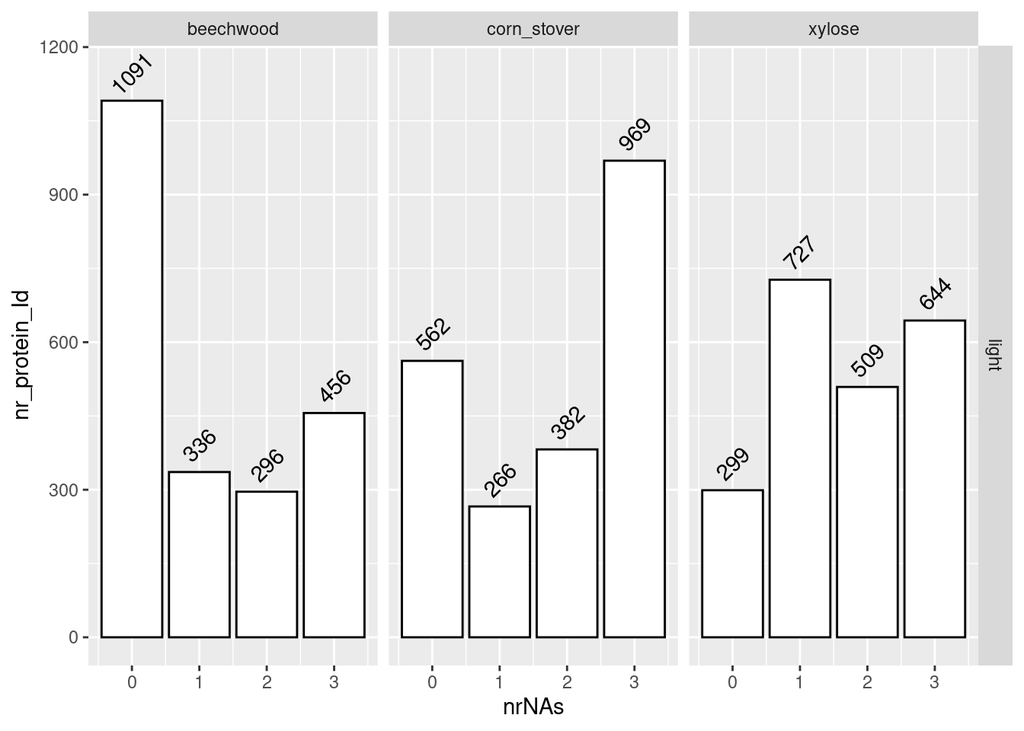

Figure 20: Cumulative protein MVs per condition

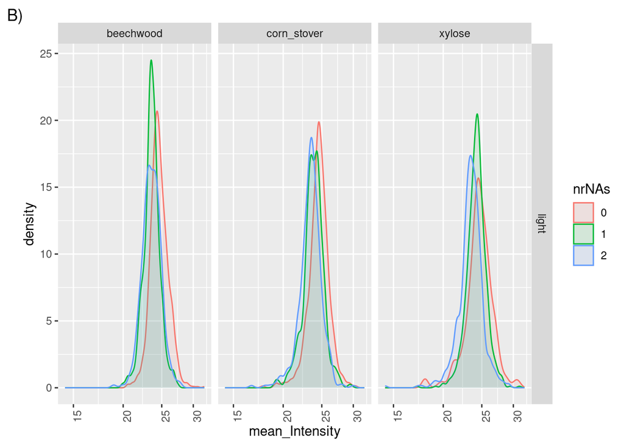

Figure 21: Density of proteins with 0, 1 or 2 MVs per condition.

```r
p1_mv
p2_mv
```

```r
formula_Condition <- strategy_lm("Intensity ~ condition_ + extrafactor_", model_name = "lm")

Contrasts <- c("cs - xyl" = "condition_corn_stover - condition_xylose", "bw - xyl" = "condition_beechwood - condition_xylose", "bw - cs" = "condition_beechwood - condition_corn_stover")

mod <- prolfqua::build_model( lfqdata$data,
                              formula_Condition,
                              subject_Id = lfqdata$config$table$hierarchy_keys())
contr <- prolfqua::Contrasts$new(mod, Contrasts)
v1 <- contr$get_Plotter()$volcano()
mC <- ContrastsMissing$new(lfqdata = lfqdata, contrasts = Contrasts)
merged <- prolfqua::merge_contrasts_results(prefer = contr,add = mC)$merged
merged <- prolfqua::ContrastsModerated$new(merged)
moderated_v1_mc <- merged$get_Plotter()$volcano()

de_test <- moderated_v1_mc$FDR$data
de_test <- de_test %>% filter(protein_Id %in% rownames(mp_df_quant))
write.csv(data.frame(de_test),gzfile("results/MS/prolfqua_unfiltered_moderated_v1_mc.csv.gz"), row.names = FALSE)
```

Here we see that the biological factor (condition) drives variation much more than the experimenta/MS batches (extrafactor). We have already checked this with [BatchQC](https://www.bioconductor.org/packages/release/bioc/html/BatchQC.html) and clustering techniques like PCA and dendrograms.

We see the effect of batch (extrafactor_) and the much larger effect of substrate (condition_) in the p-values distribution.

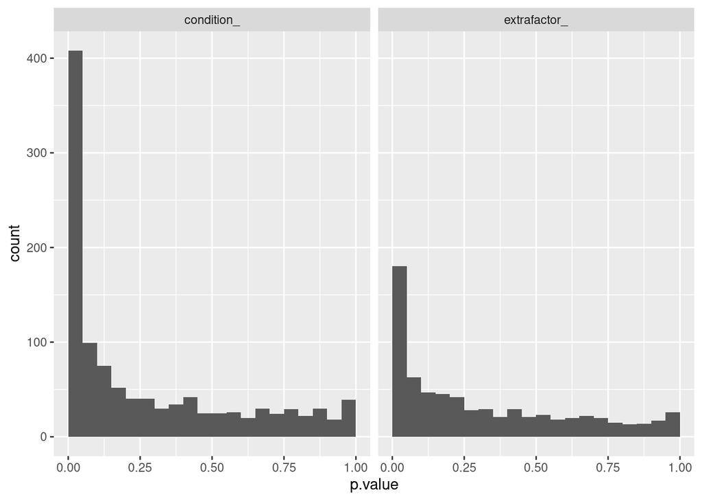

Figure 22: Histogram of p-values.

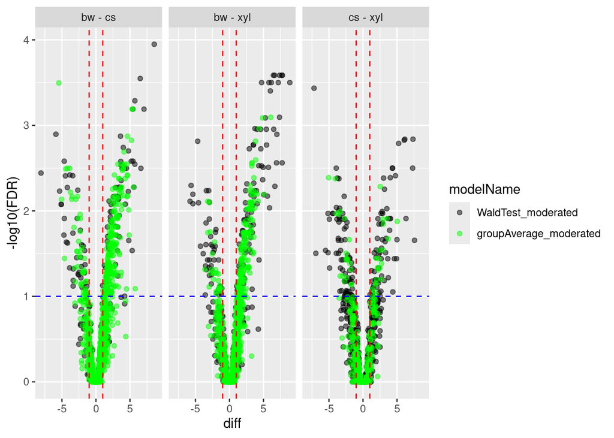

Figure 23: Volcano plot of log10 adjusted p-values and log2 fold-change.

```r
mod$anova_histogram()$plot
moderated_v1_mc$FDR
```

We see most induced proteins are in beechwood.

```r
comparisons <- c("cs - xyl", "bw - xyl", "bw - cs")

de_results <- data.frame(
  Comparison = character(),
  Up = integer(),
  Down = integer()
)

for (comp in comparisons) {
  up_prots <- de_test %>% filter(contrast == comp  & FDR < 0.05  & diff > 0) %>% nrow()
  down_prots <- de_test %>% filter(contrast == comp  & FDR < 0.05  & diff < 0) %>% nrow()
  de_results <- rbind(de_results,
                      data.frame(Comparison = comp,Up = up_prots,Down = down_prots
    ))
}

knitr::kable(de_results, caption = "# of DEPs per comparison.")
```

# of DEPs per comparison.

| Comparison | Up | Down |
| --- | --- | --- |
| cs - xyl | 58 | 60 |
| bw - xyl | 178 | 40 |
| bw - cs | 194 | 54 |